# Az if-es feladat

Ebben a notebook-ban a hirhedt `if`-es feladata beérkezett megoldásokat fogjuk elemezni. Először is töltsük be a már megszokott könyvtárakat!

```python
%pylab inline
import json
#import mpld3
#mpld3.enable_notebook()
```

A notebook-okon kívül egy külön adatfile-ba kigyűjtöttem hogy melyik notebook volt helyes és melyik nem. Ezt az információt az `isgood` `dict`-be töltöm bele:

```python
isgood=dict(list(map(lambda x:[x[0].decode('ascii'),x[1].decode('ascii')],loadtxt('data/helyes-e',dtype='S'))))
```

A már megszokott módon a files tömbbe berakjuk a notebook fileok nevét

```python
files=!ls data/*.ipynb
```

és a fileokból kibányásszuk a kódcellákat:

```python
dat=dict()
for ff in files:
    nb=open(ff);
    nb=json.load(nb);
    dat[ff[5:11]]=nb
    if (array(nb['cells'])[array(list(map(lambda x:x['cell_type']=='code',nb['cells'])))]).any():
        dat[ff[5:11]]=array(nb['cells'])[array(list(map(lambda x:x['cell_type']=='code',nb['cells'])))]

aldat=dict()
for nept in dat:
    tmp=''
    for  src in dat[nept]:
        if (src['source']):
            tmp+=''.join(src['source'])
    aldat[nept]=tmp
```

Az alábbi ábrán azt vizsgáljuk meg, hogy a megírt kód hosszúságának a függvényében hány `if`, `elif` és `else` szerepelt az adott notebookban.

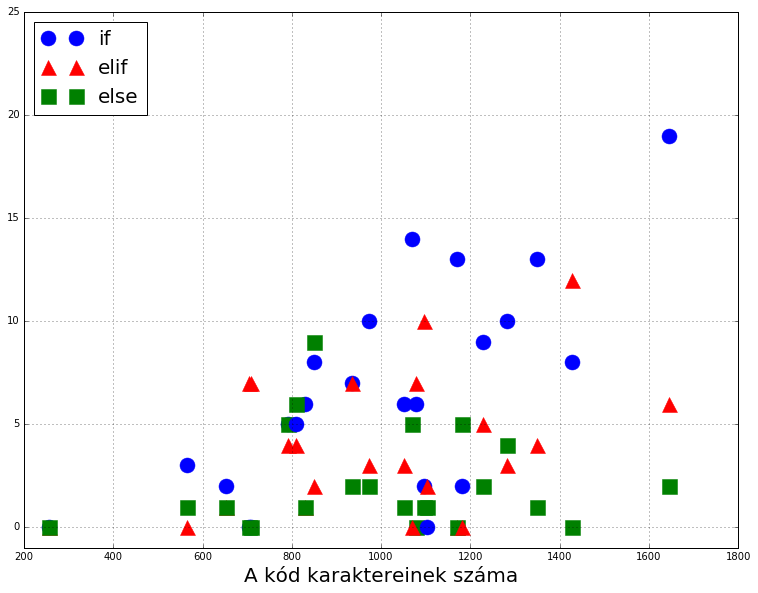

```python
figsize(2*6.4,2*4.8)
lblif='if';
lblelif='elif';
lblelse='else';
for nept in aldat:
    plot(len(aldat[nept]),aldat[nept].count(' if'),'o',
         markerfacecolor='blue',markeredgecolor='blue',
        ms=15,label=lblif);lblif='_if';
    plot(len(aldat[nept]),aldat[nept].count('elif'),'^',
         markerfacecolor='red',markeredgecolor='red',
        ms=15,label=lblelif);lblelif='_elif';
    plot(len(aldat[nept]),aldat[nept].count('else'),'s',
         markerfacecolor='green',markeredgecolor='green',
        ms=15,label=lblelse);lblelse='_else';

legend(loc="upper left",fontsize=20);
xlabel("A kód karaktereinek száma",fontsize=20);
ylim(-1,25)
xlim(200,1800)
grid()
```

Az ábrából talán azt a nem túl meglepő következtetést lehet levonni, hogy általában minnél több `if`-et használt valaki annál hosszabb lett a kódja. Meglepő viszont hogy az `else`-k száma inkább függetlennek tűnik kód karaktereinek számától!

Vizsgáljuk meg azt hogy vajon a helyes megoldást beküldők milyen hosszú kódot illetve milyen választékosan szerkeztett programot írtak! Az alábbi ábrán a kód hosszának függvényében ábrázoljuk minden adott programban az `else` kulcsszavak számát. A használt marker mérete pedig az `if`-ek számával arányos.

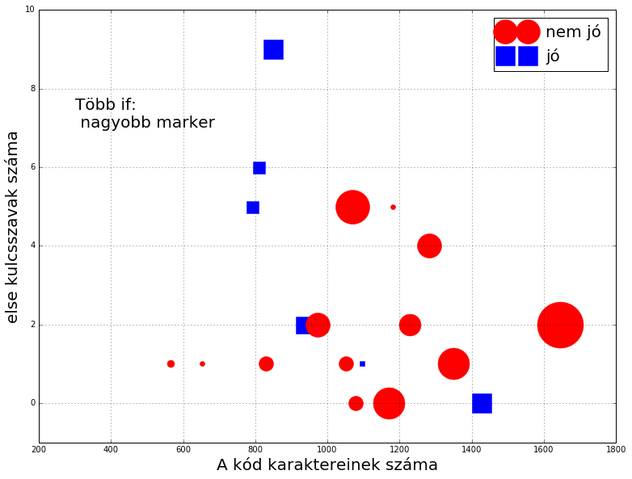

```python
figsize(2*6.4,2*4.8)
lblgood='jó';
lblnogood='nem jó';
for nept in aldat:
    if isgood[nept]=='igen':
     plot(len(aldat[nept]),aldat[nept].count('else'),'s',
        ms=3*aldat[nept].count(' if'),
        markerfacecolor='blue',markeredgecolor='blue',
         label=lblgood);lblgood='_'
    else:
     plot(len(aldat[nept]),aldat[nept].count('else'),'o',
        ms=3*aldat[nept].count(' if'),
        markerfacecolor='red',markeredgecolor='red',
         label=lblnogood);lblnogood='_'
ylim(-1,10)
legend(fontsize=20)
xlabel("A kód karaktereinek száma",fontsize=20);
ylabel('else kulcsszavak száma',fontsize=20)
text(300,7,'Több if:\n nagyobb marker',fontsize=20)
grid()
savefig('ifelifelse.png',transparent=False)
```

Az alábbi ábra az `elif` kulcsszavak számát ábrázolja a fenti ábrával hasonló módon:

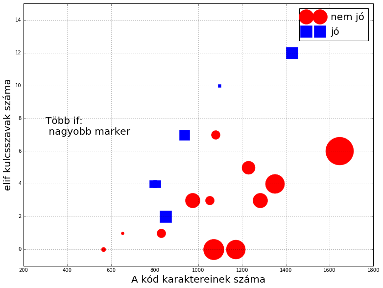

```python
figsize(2*6.4,2*4.8)
lblgood='jó';
lblnogood='nem jó';
for nept in aldat:
    if isgood[nept]=='igen':
     plot(len(aldat[nept]),aldat[nept].count('elif'),'s',
        ms=3*aldat[nept].count(' if'),
        markerfacecolor='blue',markeredgecolor='blue',
         label=lblgood);lblgood='_'
    else:
     plot(len(aldat[nept]),aldat[nept].count('elif'),'o',
        ms=3*aldat[nept].count(' if'),
        markerfacecolor='red',markeredgecolor='red',
         label=lblnogood);lblnogood='_'
ylim(-1,15)
legend(fontsize=20)
xlabel("A kód karaktereinek száma",fontsize=20);
ylabel('elif kulcsszavak száma',fontsize=20)
text(300,7,'Több if:\n nagyobb marker',fontsize=20)
grid()
```

Alapvetően azt a következtetést vonhatjuk le hogy a rövidebb és a nyelv gazdagségát jobban kihasználó programok, jobban átláthatóak és ezért nagy valószínűséggel kevesebb bennük a hiba.